# Risk Factor Analysis

## Outcome Variable

**Outcome Variable:** haz

## Predictor Variables

**Intervention Variable:** mbmi

**Adjustment Set:**

- arm
- W_mage
- meducyrs
- feducyrs
- hhwealth_quart
- brthmon
- W_parity
- impfloor
- impsan
- safeh20
- delta_W_mage
- delta_meducyrs
- delta_feducyrs
- delta_hhwealth_quart
- delta_brthmon
- delta_W_parity
- delta_impfloor
- delta_impsan
- delta_safeh20

## Stratifying Variables

The analysis was stratified on these variable(s):

- agecat
- studyid
- country

## Data Summary

| agecat | studyid | country | mbmi | n_cell | n |
| --- | --- | --- | --- | --- | --- |
| Birth | JiVitA-3 | BANGLADESH | Normal weight | 13720 | 22355 |
| Birth | JiVitA-3 | BANGLADESH | Underweight | 8635 | 22355 |
| Birth | MAL-ED | BANGLADESH | Normal weight | 194 | 222 |
| Birth | MAL-ED | BANGLADESH | Underweight | 28 | 222 |
| Birth | MAL-ED | BRAZIL | Normal weight | 59 | 64 |
| Birth | MAL-ED | BRAZIL | Underweight | 5 | 64 |
| Birth | MAL-ED | INDIA | Normal weight | 35 | 43 |
| Birth | MAL-ED | INDIA | Underweight | 8 | 43 |
| Birth | MAL-ED | NEPAL | Normal weight | 27 | 27 |
| Birth | MAL-ED | NEPAL | Underweight | 0 | 27 |
| Birth | MAL-ED | PERU | Normal weight | 221 | 226 |
| Birth | MAL-ED | PERU | Underweight | 5 | 226 |
| Birth | MAL-ED | SOUTH AFRICA | Normal weight | 98 | 101 |
| Birth | MAL-ED | SOUTH AFRICA | Underweight | 3 | 101 |
| Birth | MAL-ED | TANZANIA, UNITED REPUBLIC OF | Normal weight | 115 | 122 |
| Birth | MAL-ED | TANZANIA, UNITED REPUBLIC OF | Underweight | 7 | 122 |
| Birth | NIH-Birth | BANGLADESH | Normal weight | 506 | 608 |
| Birth | NIH-Birth | BANGLADESH | Underweight | 102 | 608 |
| Birth | NIH-Crypto | BANGLADESH | Normal weight | 663 | 729 |
| Birth | NIH-Crypto | BANGLADESH | Underweight | 66 | 729 |
| Birth | PROBIT | BELARUS | Normal weight | 13203 | 13726 |
| Birth | PROBIT | BELARUS | Underweight | 523 | 13726 |
| Birth | PROVIDE | BANGLADESH | Normal weight | 418 | 517 |
| Birth | PROVIDE | BANGLADESH | Underweight | 99 | 517 |
| Birth | SAS-CompFeed | INDIA | Normal weight | 830 | 1135 |
| Birth | SAS-CompFeed | INDIA | Underweight | 305 | 1135 |
| Birth | ZVITAMBO | ZIMBABWE | Normal weight | 9162 | 9672 |
| Birth | ZVITAMBO | ZIMBABWE | Underweight | 510 | 9672 |
| 6 months | JiVitA-3 | BANGLADESH | Normal weight | 10311 | 16760 |
| 6 months | JiVitA-3 | BANGLADESH | Underweight | 6449 | 16760 |

[output cut: 60 more lines]

The following strata were considered:

- agecat: 24 months, studyid: JiVitA-3, country: BANGLADESH
- agecat: 24 months, studyid: LCNI-5, country: MALAWI
- agecat: 24 months, studyid: MAL-ED, country: BANGLADESH
- agecat: 24 months, studyid: MAL-ED, country: BRAZIL
- agecat: 24 months, studyid: MAL-ED, country: INDIA
- agecat: 24 months, studyid: MAL-ED, country: NEPAL
- agecat: 24 months, studyid: MAL-ED, country: PERU
- agecat: 24 months, studyid: MAL-ED, country: SOUTH AFRICA
- agecat: 24 months, studyid: MAL-ED, country: TANZANIA, UNITED REPUBLIC OF
- agecat: 24 months, studyid: NIH-Birth, country: BANGLADESH
- agecat: 24 months, studyid: NIH-Crypto, country: BANGLADESH
- agecat: 24 months, studyid: PROBIT, country: BELARUS
- agecat: 24 months, studyid: PROVIDE, country: BANGLADESH
- agecat: 24 months, studyid: TanzaniaChild2, country: TANZANIA, UNITED REPUBLIC OF
- agecat: 24 months, studyid: ZVITAMBO, country: ZIMBABWE
- agecat: 6 months, studyid: JiVitA-3, country: BANGLADESH
- agecat: 6 months, studyid: LCNI-5, country: MALAWI
- agecat: 6 months, studyid: MAL-ED, country: BANGLADESH
- agecat: 6 months, studyid: MAL-ED, country: BRAZIL
- agecat: 6 months, studyid: MAL-ED, country: INDIA
- agecat: 6 months, studyid: MAL-ED, country: NEPAL
- agecat: 6 months, studyid: MAL-ED, country: PERU
- agecat: 6 months, studyid: MAL-ED, country: SOUTH AFRICA
- agecat: 6 months, studyid: MAL-ED, country: TANZANIA, UNITED REPUBLIC OF
- agecat: 6 months, studyid: NIH-Birth, country: BANGLADESH
- agecat: 6 months, studyid: NIH-Crypto, country: BANGLADESH
- agecat: 6 months, studyid: PROBIT, country: BELARUS
- agecat: 6 months, studyid: PROVIDE, country: BANGLADESH
- agecat: 6 months, studyid: SAS-CompFeed, country: INDIA
- agecat: 6 months, studyid: TanzaniaChild2, country: TANZANIA, UNITED REPUBLIC OF
- agecat: 6 months, studyid: ZVITAMBO, country: ZIMBABWE
- agecat: Birth, studyid: JiVitA-3, country: BANGLADESH
- agecat: Birth, studyid: MAL-ED, country: BANGLADESH
- agecat: Birth, studyid: MAL-ED, country: BRAZIL
- agecat: Birth, studyid: MAL-ED, country: INDIA
- agecat: Birth, studyid: MAL-ED, country: NEPAL
- agecat: Birth, studyid: MAL-ED, country: PERU
- agecat: Birth, studyid: MAL-ED, country: SOUTH AFRICA
- agecat: Birth, studyid: MAL-ED, country: TANZANIA, UNITED REPUBLIC OF
- agecat: Birth, studyid: NIH-Birth, country: BANGLADESH
- agecat: Birth, studyid: NIH-Crypto, country: BANGLADESH
- agecat: Birth, studyid: PROBIT, country: BELARUS
- agecat: Birth, studyid: PROVIDE, country: BANGLADESH
- agecat: Birth, studyid: SAS-CompFeed, country: INDIA
- agecat: Birth, studyid: ZVITAMBO, country: ZIMBABWE

### Dropped Strata

Some strata were dropped due to rare outcomes:

- agecat: Birth, studyid: MAL-ED, country: NEPAL
- agecat: Birth, studyid: MAL-ED, country: SOUTH AFRICA
- agecat: 6 months, studyid: MAL-ED, country: NEPAL
- agecat: 24 months, studyid: MAL-ED, country: NEPAL
- agecat: 24 months, studyid: MAL-ED, country: PERU
- agecat: 24 months, studyid: TanzaniaChild2, country: TANZANIA, UNITED REPUBLIC OF

## Methods Detail

We’re interested in the causal parameters $E[Y_a]$ for all values of $a \in \mathcal{A}$. These parameters represent the mean outcome if, possibly contrary to fact, we intervened to set all units to have $A=a$. Under the randomization and positivity assumptions, these are identified by the statistical parameters $\psi_a=E_W[E_{Y|A,W}(Y|A=a,W)]$. In addition, we’re interested in the mean of $Y$, $E[Y]$ under no intervention (the observed mean). We will estimate these parameters by using SuperLearner to fit the relevant likelihood factors – $E_{Y|A,W}(Y|A=a,W)$ and $p(A=a|W)$, and then updating our likelihood fit using a joint TMLE.

For unadjusted analyses ($W=\{\}$), initial likelihoods were estimated using Lrnr_glm to estimate the simple $E(Y|A)$ and Lrnr_mean to estimate $p(A)$. For adjusted analyses, a small library containing Lrnr_glmnet, Lrnr_xgboost, and Lrnr_mean was used.

Having estimated these parameters, we will then use the delta method to estimate relative risks and attributable risks relative to a prespecified baseline level of $A$.

# Results Detail

## Results Plots

[figure not shown]

[figure not shown]

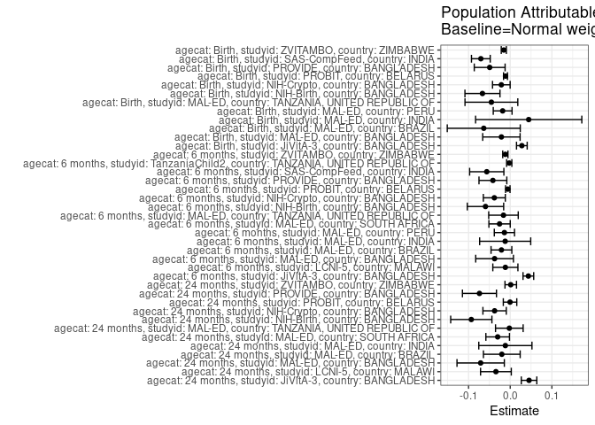

## Results Table

### Parameter: TSM

| agecat | studyid | country | intervention_level | baseline_level | estimate | ci_lower | ci_upper |
| --- | --- | --- | --- | --- | --- | --- | --- |
| Birth | JiVitA-3 | BANGLADESH | Normal weight | NA | -1.6172169 | -1.6403402 | -1.5940936 |
| Birth | JiVitA-3 | BANGLADESH | Underweight | NA | -1.5454260 | -1.5734714 | -1.5173805 |
| Birth | MAL-ED | BANGLADESH | Normal weight | NA | -1.0567234 | -1.2032109 | -0.9102359 |
| Birth | MAL-ED | BANGLADESH | Underweight | NA | -1.1932758 | -1.5633616 | -0.8231899 |
| Birth | MAL-ED | BRAZIL | Normal weight | NA | -0.6249153 | -0.9137560 | -0.3360745 |
| Birth | MAL-ED | BRAZIL | Underweight | NA | -1.4380000 | -2.2732876 | -0.6027124 |
| Birth | MAL-ED | INDIA | Normal weight | NA | -1.2745714 | -1.6299983 | -0.9191446 |
| Birth | MAL-ED | INDIA | Underweight | NA | -1.0362500 | -1.6020040 | -0.4704960 |
| Birth | MAL-ED | PERU | Normal weight | NA | -0.8869683 | -1.0065725 | -0.7673641 |
| Birth | MAL-ED | PERU | Underweight | NA | -1.7080000 | -2.3409322 | -1.0750678 |
| Birth | MAL-ED | TANZANIA, UNITED REPUBLIC OF | Normal weight | NA | -1.0913043 | -1.3056634 | -0.8769453 |
| Birth | MAL-ED | TANZANIA, UNITED REPUBLIC OF | Underweight | NA | -1.8785714 | -2.8008825 | -0.9562603 |
| Birth | NIH-Birth | BANGLADESH | Normal weight | NA | -0.8643877 | -0.9593084 | -0.7694670 |
| Birth | NIH-Birth | BANGLADESH | Underweight | NA | -1.2471283 | -1.4799507 | -1.0143059 |
| Birth | NIH-Crypto | BANGLADESH | Normal weight | NA | -0.8875805 | -0.9637552 | -0.8114059 |
| Birth | NIH-Crypto | BANGLADESH | Underweight | NA | -1.1537762 | -1.3748865 | -0.9326659 |
| Birth | PROBIT | BELARUS | Normal weight | NA | 1.3231639 | 1.1630562 | 1.4832717 |
| Birth | PROBIT | BELARUS | Underweight | NA | 0.9721589 | 0.7858457 | 1.1584721 |
| Birth | PROVIDE | BANGLADESH | Normal weight | NA | -0.8432235 | -0.9279785 | -0.7584686 |
| Birth | PROVIDE | BANGLADESH | Underweight | NA | -1.1224848 | -1.2987248 | -0.9462448 |
| Birth | SAS-CompFeed | INDIA | Normal weight | NA | -1.3733276 | -1.4687330 | -1.2779222 |
| Birth | SAS-CompFeed | INDIA | Underweight | NA | -1.6367608 | -1.7433420 | -1.5301795 |
| Birth | ZVITAMBO | ZIMBABWE | Normal weight | NA | -0.4610391 | -0.4861056 | -0.4359727 |
| Birth | ZVITAMBO | ZIMBABWE | Underweight | NA | -0.7670019 | -0.8854531 | -0.6485506 |
| 6 months | JiVitA-3 | BANGLADESH | Normal weight | NA | -1.3575322 | -1.3843552 | -1.3307092 |
| 6 months | JiVitA-3 | BANGLADESH | Underweight | NA | -1.2450996 | -1.2756419 | -1.2145572 |
| 6 months | LCNI-5 | MALAWI | Normal weight | NA | -1.6461262 | -1.7246144 | -1.5676379 |
| 6 months | LCNI-5 | MALAWI | Underweight | NA | -1.7037688 | -1.8618393 | -1.5456983 |
| 6 months | MAL-ED | BANGLADESH | Normal weight | NA | -1.1674523 | -1.2930335 | -1.0418712 |
| 6 months | MAL-ED | BANGLADESH | Underweight | NA | -1.4590591 | -1.7638998 | -1.1542184 |
| 6 months | MAL-ED | BRAZIL | Normal weight | NA | 0.0708375 | -0.0781476 | 0.2198227 |
| 6 months | MAL-ED | BRAZIL | Underweight | NA | -0.4164815 | -0.8769172 | 0.0439543 |
| 6 months | MAL-ED | INDIA | Normal weight | NA | -1.1938530 | -1.3270600 | -1.0606459 |
| 6 months | MAL-ED | INDIA | Underweight | NA | -1.2406280 | -1.5091220 | -0.9721340 |
| 6 months | MAL-ED | PERU | Normal weight | NA | -1.3101467 | -1.4185443 | -1.2017491 |
| 6 months | MAL-ED | PERU | Underweight | NA | -2.0693333 | -2.9031517 | -1.2355150 |
| 6 months | MAL-ED | SOUTH AFRICA | Normal weight | NA | -1.0471625 | -1.1780920 | -0.9162331 |
| 6 months | MAL-ED | SOUTH AFRICA | Underweight | NA | -1.9571429 | -2.5636947 | -1.3505910 |
| 6 months | MAL-ED | TANZANIA, UNITED REPUBLIC OF | Normal weight | NA | -1.3525388 | -1.4765475 | -1.2285300 |
| 6 months | MAL-ED | TANZANIA, UNITED REPUBLIC OF | Underweight | NA | -1.2497368 | -1.9382649 | -0.5612087 |
| 6 months | NIH-Birth | BANGLADESH | Normal weight | NA | -1.3480036 | -1.4430294 | -1.2529778 |
| 6 months | NIH-Birth | BANGLADESH | Underweight | NA | -1.6986445 | -1.9369742 | -1.4603147 |
| 6 months | NIH-Crypto | BANGLADESH | Normal weight | NA | -1.1605401 | -1.2346389 | -1.0864414 |
| 6 months | NIH-Crypto | BANGLADESH | Underweight | NA | -1.5829709 | -1.8534767 | -1.3124650 |
| 6 months | PROBIT | BELARUS | Normal weight | NA | 0.1134514 | 0.0235321 | 0.2033707 |
| 6 months | PROBIT | BELARUS | Underweight | NA | -0.0418949 | -0.2250495 | 0.1412598 |
| 6 months | PROVIDE | BANGLADESH | Normal weight | NA | -1.0479668 | -1.1308914 | -0.9650423 |
| 6 months | PROVIDE | BANGLADESH | Underweight | NA | -1.3067623 | -1.4769712 | -1.1365533 |
| 6 months | SAS-CompFeed | INDIA | Normal weight | NA | -1.3505682 | -1.4534104 | -1.2477259 |
| 6 months | SAS-CompFeed | INDIA | Underweight | NA | -1.5790690 | -1.7226816 | -1.4354564 |
| 6 months | TanzaniaChild2 | TANZANIA, UNITED REPUBLIC OF | Normal weight | NA | -0.5381968 | -0.5884781 | -0.4879156 |
| 6 months | TanzaniaChild2 | TANZANIA, UNITED REPUBLIC OF | Underweight | NA | -0.5909946 | -0.8431364 | -0.3388528 |
| 6 months | ZVITAMBO | ZIMBABWE | Normal weight | NA | -0.8683376 | -0.8965240 | -0.8401513 |
| 6 months | ZVITAMBO | ZIMBABWE | Underweight | NA | -1.1069791 | -1.2310489 | -0.9829094 |
| 24 months | JiVitA-3 | BANGLADESH | Normal weight | NA | -2.0589519 | -2.0927329 | -2.0251708 |
| 24 months | JiVitA-3 | BANGLADESH | Underweight | NA | -1.9420381 | -1.9819873 | -1.9020890 |
| 24 months | LCNI-5 | MALAWI | Normal weight | NA | -1.8508586 | -1.9399227 | -1.7617945 |
| 24 months | LCNI-5 | MALAWI | Underweight | NA | -1.9692043 | -2.1762108 | -1.7621977 |
| 24 months | MAL-ED | BANGLADESH | Normal weight | NA | -1.9074646 | -2.0385075 | -1.7764217 |
| 24 months | MAL-ED | BANGLADESH | Underweight | NA | -2.4194923 | -2.8031746 | -2.0358100 |
| 24 months | MAL-ED | BRAZIL | Normal weight | NA | 0.0261008 | -0.1439691 | 0.1961708 |
| 24 months | MAL-ED | BRAZIL | Underweight | NA | -0.5391667 | -1.6773310 | 0.5989977 |
| 24 months | MAL-ED | INDIA | Normal weight | NA | -1.8728242 | -2.0136469 | -1.7320014 |
| 24 months | MAL-ED | INDIA | Underweight | NA | -1.9272759 | -2.2179655 | -1.6365864 |
| 24 months | MAL-ED | SOUTH AFRICA | Normal weight | NA | -1.6131241 | -1.7506877 | -1.4755605 |
| 24 months | MAL-ED | SOUTH AFRICA | Underweight | NA | -2.6192857 | -3.1998173 | -2.0387542 |
| 24 months | MAL-ED | TANZANIA, UNITED REPUBLIC OF | Normal weight | NA | -2.6434238 | -2.7819221 | -2.5049255 |
| 24 months | MAL-ED | TANZANIA, UNITED REPUBLIC OF | Underweight | NA | -2.7020739 | -3.3572583 | -2.0468895 |
| 24 months | NIH-Birth | BANGLADESH | Normal weight | NA | -2.1256569 | -2.2386032 | -2.0127107 |
| 24 months | NIH-Birth | BANGLADESH | Underweight | NA | -2.6382448 | -2.8590509 | -2.4174388 |
| 24 months | NIH-Crypto | BANGLADESH | Normal weight | NA | -1.4037767 | -1.4903547 | -1.3171987 |
| 24 months | NIH-Crypto | BANGLADESH | Underweight | NA | -1.8516560 | -2.1507068 | -1.5526052 |
| 24 months | PROBIT | BELARUS | Normal weight | NA | -0.1439799 | -0.4290827 | 0.1411229 |
| 24 months | PROBIT | BELARUS | Underweight | NA | -0.1608168 | -0.6264726 | 0.3048389 |
| 24 months | PROVIDE | BANGLADESH | Normal weight | NA | -1.5264190 | -1.6165275 | -1.4363105 |
| 24 months | PROVIDE | BANGLADESH | Underweight | NA | -1.9750831 | -2.1842509 | -1.7659153 |
| 24 months | ZVITAMBO | ZIMBABWE | Normal weight | NA | -1.5995767 | -1.6632609 | -1.5358925 |
| 24 months | ZVITAMBO | ZIMBABWE | Underweight | NA | -1.7354182 | -2.0691384 | -1.4016980 |

### Parameter: E(Y)

| agecat | studyid | country | intervention_level | baseline_level | estimate | ci_lower | ci_upper |
| --- | --- | --- | --- | --- | --- | --- | --- |
| Birth | JiVitA-3 | BANGLADESH | NA | NA | -1.5893196 | -1.6086080 | -1.5700313 |
| Birth | MAL-ED | BANGLADESH | NA | NA | -1.0778829 | -1.2122580 | -0.9435077 |
| Birth | MAL-ED | BRAZIL | NA | NA | -0.6884375 | -0.9678371 | -0.4090379 |
| Birth | MAL-ED | INDIA | NA | NA | -1.2302326 | -1.5393614 | -0.9211037 |
| Birth | MAL-ED | PERU | NA | NA | -0.9051327 | -1.0238686 | -0.7863969 |
| Birth | MAL-ED | TANZANIA, UNITED REPUBLIC OF | NA | NA | -1.1364754 | -1.3478823 | -0.9250686 |
| Birth | NIH-Birth | BANGLADESH | NA | NA | -0.9310197 | -1.0197391 | -0.8423003 |
| Birth | NIH-Crypto | BANGLADESH | NA | NA | -0.9089163 | -0.9806324 | -0.8372002 |
| Birth | PROBIT | BELARUS | NA | NA | 1.3118585 | 1.1523374 | 1.4713797 |
| Birth | PROVIDE | BANGLADESH | NA | NA | -0.8925145 | -0.9687201 | -0.8163089 |
| Birth | SAS-CompFeed | INDIA | NA | NA | -1.4438150 | -1.5337502 | -1.3538797 |
| Birth | ZVITAMBO | ZIMBABWE | NA | NA | -0.4764413 | -0.5009156 | -0.4519670 |
| 6 months | JiVitA-3 | BANGLADESH | NA | NA | -1.3140048 | -1.3371141 | -1.2908955 |
| 6 months | LCNI-5 | MALAWI | NA | NA | -1.6577751 | -1.7275296 | -1.5880207 |
| 6 months | MAL-ED | BANGLADESH | NA | NA | -1.2049931 | -1.3222136 | -1.0877726 |
| 6 months | MAL-ED | BRAZIL | NA | NA | 0.0497516 | -0.0948051 | 0.1943083 |
| 6 months | MAL-ED | INDIA | NA | NA | -1.2059574 | -1.3243030 | -1.0876119 |
| 6 months | MAL-ED | PERU | NA | NA | -1.3241023 | -1.4325083 | -1.2156964 |
| 6 months | MAL-ED | SOUTH AFRICA | NA | NA | -1.0727443 | -1.2024880 | -0.9430006 |
| 6 months | MAL-ED | TANZANIA, UNITED REPUBLIC OF | NA | NA | -1.3687449 | -1.4907629 | -1.2467270 |
| 6 months | NIH-Birth | BANGLADESH | NA | NA | -1.4073821 | -1.4960598 | -1.3187043 |
| 6 months | NIH-Crypto | BANGLADESH | NA | NA | -1.1986783 | -1.2700937 | -1.1272630 |
| 6 months | PROBIT | BELARUS | NA | NA | 0.1076224 | 0.0168411 | 0.1984037 |
| 6 months | PROVIDE | BANGLADESH | NA | NA | -1.0895301 | -1.1639589 | -1.0151013 |
| 6 months | SAS-CompFeed | INDIA | NA | NA | -1.4068893 | -1.4981242 | -1.3156543 |
| 6 months | TanzaniaChild2 | TANZANIA, UNITED REPUBLIC OF | NA | NA | -0.5405711 | -0.5899965 | -0.4911457 |
| 6 months | ZVITAMBO | ZIMBABWE | NA | NA | -0.8800508 | -0.9074511 | -0.8526506 |
| 24 months | JiVitA-3 | BANGLADESH | NA | NA | -2.0137632 | -2.0415122 | -1.9860142 |
| 24 months | LCNI-5 | MALAWI | NA | NA | -1.8851820 | -1.9664818 | -1.8038822 |
| 24 months | MAL-ED | BANGLADESH | NA | NA | -1.9783962 | -2.1050210 | -1.8517715 |
| 24 months | MAL-ED | BRAZIL | NA | NA | 0.0059127 | -0.1637934 | 0.1756188 |
| 24 months | MAL-ED | INDIA | NA | NA | -1.8844690 | -2.0097879 | -1.7591502 |
| 24 months | MAL-ED | SOUTH AFRICA | NA | NA | -1.6432229 | -1.7795844 | -1.5068615 |
| 24 months | MAL-ED | TANZANIA, UNITED REPUBLIC OF | NA | NA | -2.6455607 | -2.7807256 | -2.5103959 |
| 24 months | NIH-Birth | BANGLADESH | NA | NA | -2.2190579 | -2.3217459 | -2.1163699 |
| 24 months | NIH-Crypto | BANGLADESH | NA | NA | -1.4412646 | -1.5249156 | -1.3576135 |
| 24 months | PROBIT | BELARUS | NA | NA | -0.1444149 | -0.4258602 | 0.1370304 |
| 24 months | PROVIDE | BANGLADESH | NA | NA | -1.6002600 | -1.6836163 | -1.5169036 |
| 24 months | ZVITAMBO | ZIMBABWE | NA | NA | -1.5983212 | -1.6605141 | -1.5361283 |

### Parameter: ATE

| agecat | studyid | country | intervention_level | baseline_level | estimate | ci_lower | ci_upper |
| --- | --- | --- | --- | --- | --- | --- | --- |
| Birth | JiVitA-3 | BANGLADESH | Normal weight | Normal weight | 0.0000000 | 0.0000000 | 0.0000000 |
| Birth | JiVitA-3 | BANGLADESH | Underweight | Normal weight | 0.0717910 | 0.0386952 | 0.1048867 |
| Birth | MAL-ED | BANGLADESH | Normal weight | Normal weight | 0.0000000 | 0.0000000 | 0.0000000 |
| Birth | MAL-ED | BANGLADESH | Underweight | Normal weight | -0.1365523 | -0.5349811 | 0.2618764 |
| Birth | MAL-ED | BRAZIL | Normal weight | Normal weight | 0.0000000 | 0.0000000 | 0.0000000 |
| Birth | MAL-ED | BRAZIL | Underweight | Normal weight | -0.8130847 | -1.6969028 | 0.0707333 |
| Birth | MAL-ED | INDIA | Normal weight | Normal weight | 0.0000000 | 0.0000000 | 0.0000000 |
| Birth | MAL-ED | INDIA | Underweight | Normal weight | 0.2383214 | -0.4298147 | 0.9064576 |
| Birth | MAL-ED | PERU | Normal weight | Normal weight | 0.0000000 | 0.0000000 | 0.0000000 |
| Birth | MAL-ED | PERU | Underweight | Normal weight | -0.8210317 | -1.4651655 | -0.1768979 |
| Birth | MAL-ED | TANZANIA, UNITED REPUBLIC OF | Normal weight | Normal weight | 0.0000000 | 0.0000000 | 0.0000000 |
| Birth | MAL-ED | TANZANIA, UNITED REPUBLIC OF | Underweight | Normal weight | -0.7872671 | -1.7341607 | 0.1596266 |
| Birth | NIH-Birth | BANGLADESH | Normal weight | Normal weight | 0.0000000 | 0.0000000 | 0.0000000 |
| Birth | NIH-Birth | BANGLADESH | Underweight | Normal weight | -0.3827406 | -0.6341638 | -0.1313174 |
| Birth | NIH-Crypto | BANGLADESH | Normal weight | Normal weight | 0.0000000 | 0.0000000 | 0.0000000 |
| Birth | NIH-Crypto | BANGLADESH | Underweight | Normal weight | -0.2661957 | -0.4993883 | -0.0330031 |
| Birth | PROBIT | BELARUS | Normal weight | Normal weight | 0.0000000 | 0.0000000 | 0.0000000 |
| Birth | PROBIT | BELARUS | Underweight | Normal weight | -0.3510051 | -0.4797950 | -0.2222151 |
| Birth | PROVIDE | BANGLADESH | Normal weight | Normal weight | 0.0000000 | 0.0000000 | 0.0000000 |
| Birth | PROVIDE | BANGLADESH | Underweight | Normal weight | -0.2792612 | -0.4752330 | -0.0832895 |
| Birth | SAS-CompFeed | INDIA | Normal weight | Normal weight | 0.0000000 | 0.0000000 | 0.0000000 |
| Birth | SAS-CompFeed | INDIA | Underweight | Normal weight | -0.2634332 | -0.3385645 | -0.1883018 |
| Birth | ZVITAMBO | ZIMBABWE | Normal weight | Normal weight | 0.0000000 | 0.0000000 | 0.0000000 |
| Birth | ZVITAMBO | ZIMBABWE | Underweight | Normal weight | -0.3059627 | -0.4270036 | -0.1849219 |
| 6 months | JiVitA-3 | BANGLADESH | Normal weight | Normal weight | 0.0000000 | 0.0000000 | 0.0000000 |
| 6 months | JiVitA-3 | BANGLADESH | Underweight | Normal weight | 0.1124327 | 0.0791552 | 0.1457101 |
| 6 months | LCNI-5 | MALAWI | Normal weight | Normal weight | 0.0000000 | 0.0000000 | 0.0000000 |
| 6 months | LCNI-5 | MALAWI | Underweight | Normal weight | -0.0576426 | -0.2345820 | 0.1192968 |
| 6 months | MAL-ED | BANGLADESH | Normal weight | Normal weight | 0.0000000 | 0.0000000 | 0.0000000 |
| 6 months | MAL-ED | BANGLADESH | Underweight | Normal weight | -0.2916068 | -0.6214363 | 0.0382227 |
| 6 months | MAL-ED | BRAZIL | Normal weight | Normal weight | 0.0000000 | 0.0000000 | 0.0000000 |
| 6 months | MAL-ED | BRAZIL | Underweight | Normal weight | -0.4873190 | -0.9712587 | -0.0033793 |
| 6 months | MAL-ED | INDIA | Normal weight | Normal weight | 0.0000000 | 0.0000000 | 0.0000000 |
| 6 months | MAL-ED | INDIA | Underweight | Normal weight | -0.0467750 | -0.3467656 | 0.2532155 |
| 6 months | MAL-ED | PERU | Normal weight | Normal weight | 0.0000000 | 0.0000000 | 0.0000000 |
| 6 months | MAL-ED | PERU | Underweight | Normal weight | -0.7591866 | -1.6000214 | 0.0816481 |
| 6 months | MAL-ED | SOUTH AFRICA | Normal weight | Normal weight | 0.0000000 | 0.0000000 | 0.0000000 |
| 6 months | MAL-ED | SOUTH AFRICA | Underweight | Normal weight | -0.9099803 | -1.5305024 | -0.2894583 |
| 6 months | MAL-ED | TANZANIA, UNITED REPUBLIC OF | Normal weight | Normal weight | 0.0000000 | 0.0000000 | 0.0000000 |
| 6 months | MAL-ED | TANZANIA, UNITED REPUBLIC OF | Underweight | Normal weight | 0.1028020 | -0.5972991 | 0.8029031 |
| 6 months | NIH-Birth | BANGLADESH | Normal weight | Normal weight | 0.0000000 | 0.0000000 | 0.0000000 |
| 6 months | NIH-Birth | BANGLADESH | Underweight | Normal weight | -0.3506408 | -0.6072903 | -0.0939914 |
| 6 months | NIH-Crypto | BANGLADESH | Normal weight | Normal weight | 0.0000000 | 0.0000000 | 0.0000000 |
| 6 months | NIH-Crypto | BANGLADESH | Underweight | Normal weight | -0.4224307 | -0.7029924 | -0.1418691 |
| 6 months | PROBIT | BELARUS | Normal weight | Normal weight | 0.0000000 | 0.0000000 | 0.0000000 |
| 6 months | PROBIT | BELARUS | Underweight | Normal weight | -0.1553463 | -0.2968525 | -0.0138401 |
| 6 months | PROVIDE | BANGLADESH | Normal weight | Normal weight | 0.0000000 | 0.0000000 | 0.0000000 |
| 6 months | PROVIDE | BANGLADESH | Underweight | Normal weight | -0.2587954 | -0.4484314 | -0.0691594 |
| 6 months | SAS-CompFeed | INDIA | Normal weight | Normal weight | 0.0000000 | 0.0000000 | 0.0000000 |
| 6 months | SAS-CompFeed | INDIA | Underweight | Normal weight | -0.2285009 | -0.3848254 | -0.0721763 |
| 6 months | TanzaniaChild2 | TANZANIA, UNITED REPUBLIC OF | Normal weight | Normal weight | 0.0000000 | 0.0000000 | 0.0000000 |
| 6 months | TanzaniaChild2 | TANZANIA, UNITED REPUBLIC OF | Underweight | Normal weight | -0.0527977 | -0.3099656 | 0.2043701 |
| 6 months | ZVITAMBO | ZIMBABWE | Normal weight | Normal weight | 0.0000000 | 0.0000000 | 0.0000000 |
| 6 months | ZVITAMBO | ZIMBABWE | Underweight | Normal weight | -0.2386415 | -0.3658990 | -0.1113840 |
| 24 months | JiVitA-3 | BANGLADESH | Normal weight | Normal weight | 0.0000000 | 0.0000000 | 0.0000000 |
| 24 months | JiVitA-3 | BANGLADESH | Underweight | Normal weight | 0.1169137 | 0.0688519 | 0.1649756 |
| 24 months | LCNI-5 | MALAWI | Normal weight | Normal weight | 0.0000000 | 0.0000000 | 0.0000000 |
| 24 months | LCNI-5 | MALAWI | Underweight | Normal weight | -0.1183457 | -0.3442925 | 0.1076012 |
| 24 months | MAL-ED | BANGLADESH | Normal weight | Normal weight | 0.0000000 | 0.0000000 | 0.0000000 |
| 24 months | MAL-ED | BANGLADESH | Underweight | Normal weight | -0.5120278 | -0.9165317 | -0.1075238 |
| 24 months | MAL-ED | BRAZIL | Normal weight | Normal weight | 0.0000000 | 0.0000000 | 0.0000000 |
| 24 months | MAL-ED | BRAZIL | Underweight | Normal weight | -0.5652675 | -1.7160680 | 0.5855330 |
| 24 months | MAL-ED | INDIA | Normal weight | Normal weight | 0.0000000 | 0.0000000 | 0.0000000 |
| 24 months | MAL-ED | INDIA | Underweight | Normal weight | -0.0544517 | -0.3788172 | 0.2699137 |
| 24 months | MAL-ED | SOUTH AFRICA | Normal weight | Normal weight | 0.0000000 | 0.0000000 | 0.0000000 |
| 24 months | MAL-ED | SOUTH AFRICA | Underweight | Normal weight | -1.0061616 | -1.6027692 | -0.4095540 |
| 24 months | MAL-ED | TANZANIA, UNITED REPUBLIC OF | Normal weight | Normal weight | 0.0000000 | 0.0000000 | 0.0000000 |
| 24 months | MAL-ED | TANZANIA, UNITED REPUBLIC OF | Underweight | Normal weight | -0.0586501 | -0.7274009 | 0.6101006 |
| 24 months | NIH-Birth | BANGLADESH | Normal weight | Normal weight | 0.0000000 | 0.0000000 | 0.0000000 |
| 24 months | NIH-Birth | BANGLADESH | Underweight | Normal weight | -0.5125879 | -0.7599420 | -0.2652338 |
| 24 months | NIH-Crypto | BANGLADESH | Normal weight | Normal weight | 0.0000000 | 0.0000000 | 0.0000000 |
| 24 months | NIH-Crypto | BANGLADESH | Underweight | Normal weight | -0.4478792 | -0.7596724 | -0.1360861 |
| 24 months | PROBIT | BELARUS | Normal weight | Normal weight | 0.0000000 | 0.0000000 | 0.0000000 |
| 24 months | PROBIT | BELARUS | Underweight | Normal weight | -0.0168369 | -0.4801478 | 0.4464739 |
| 24 months | PROVIDE | BANGLADESH | Normal weight | Normal weight | 0.0000000 | 0.0000000 | 0.0000000 |
| 24 months | PROVIDE | BANGLADESH | Underweight | Normal weight | -0.4486641 | -0.6756041 | -0.2217240 |
| 24 months | ZVITAMBO | ZIMBABWE | Normal weight | Normal weight | 0.0000000 | 0.0000000 | 0.0000000 |
| 24 months | ZVITAMBO | ZIMBABWE | Underweight | Normal weight | -0.1358415 | -0.4754926 | 0.2038096 |

### Parameter: PAR

| agecat | studyid | country | intervention_level | baseline_level | estimate | ci_lower | ci_upper |
| --- | --- | --- | --- | --- | --- | --- | --- |
| Birth | JiVitA-3 | BANGLADESH | Normal weight | NA | 0.0278973 | 0.0150966 | 0.0406980 |
| Birth | MAL-ED | BANGLADESH | Normal weight | NA | -0.0211595 | -0.0660100 | 0.0236910 |
| Birth | MAL-ED | BRAZIL | Normal weight | NA | -0.0635222 | -0.1511062 | 0.0240617 |
| Birth | MAL-ED | INDIA | Normal weight | NA | 0.0443389 | -0.0830905 | 0.1717683 |
| Birth | MAL-ED | PERU | Normal weight | NA | -0.0181644 | -0.0407101 | 0.0043812 |
| Birth | MAL-ED | TANZANIA, UNITED REPUBLIC OF | Normal weight | NA | -0.0451711 | -0.1085427 | 0.0182006 |
| Birth | NIH-Birth | BANGLADESH | Normal weight | NA | -0.0666320 | -0.1086650 | -0.0245991 |
| Birth | NIH-Crypto | BANGLADESH | Normal weight | NA | -0.0213358 | -0.0424669 | -0.0002047 |
| Birth | PROBIT | BELARUS | Normal weight | NA | -0.0113054 | -0.0160597 | -0.0065512 |
| Birth | PROVIDE | BANGLADESH | Normal weight | NA | -0.0492910 | -0.0862923 | -0.0122897 |
| Birth | SAS-CompFeed | INDIA | Normal weight | NA | -0.0704874 | -0.0930202 | -0.0479546 |
| Birth | ZVITAMBO | ZIMBABWE | Normal weight | NA | -0.0154021 | -0.0214868 | -0.0093175 |
| 6 months | JiVitA-3 | BANGLADESH | Normal weight | NA | 0.0435275 | 0.0307119 | 0.0563430 |
| 6 months | LCNI-5 | MALAWI | Normal weight | NA | -0.0116489 | -0.0417616 | 0.0184637 |
| 6 months | MAL-ED | BANGLADESH | Normal weight | NA | -0.0375408 | -0.0827919 | 0.0077104 |
| 6 months | MAL-ED | BRAZIL | Normal weight | NA | -0.0210859 | -0.0460040 | 0.0038322 |
| 6 months | MAL-ED | INDIA | Normal weight | NA | -0.0121045 | -0.0733900 | 0.0491811 |
| 6 months | MAL-ED | PERU | Normal weight | NA | -0.0139556 | -0.0382312 | 0.0103199 |
| 6 months | MAL-ED | SOUTH AFRICA | Normal weight | NA | -0.0255818 | -0.0511699 | 0.0000064 |
| 6 months | MAL-ED | TANZANIA, UNITED REPUBLIC OF | Normal weight | NA | -0.0162062 | -0.0516439 | 0.0192316 |
| 6 months | NIH-Birth | BANGLADESH | Normal weight | NA | -0.0593784 | -0.1030230 | -0.0157339 |
| 6 months | NIH-Crypto | BANGLADESH | Normal weight | NA | -0.0381382 | -0.0645060 | -0.0117704 |
| 6 months | PROBIT | BELARUS | Normal weight | NA | -0.0058290 | -0.0111827 | -0.0004753 |
| 6 months | PROVIDE | BANGLADESH | Normal weight | NA | -0.0415633 | -0.0749451 | -0.0081814 |
| 6 months | SAS-CompFeed | INDIA | Normal weight | NA | -0.0563211 | -0.0974013 | -0.0152409 |
| 6 months | TanzaniaChild2 | TANZANIA, UNITED REPUBLIC OF | Normal weight | NA | -0.0023743 | -0.0086370 | 0.0038885 |
| 6 months | ZVITAMBO | ZIMBABWE | Normal weight | NA | -0.0117132 | -0.0179979 | -0.0054286 |
| 24 months | JiVitA-3 | BANGLADESH | Normal weight | NA | 0.0451887 | 0.0265757 | 0.0638016 |
| 24 months | LCNI-5 | MALAWI | Normal weight | NA | -0.0343234 | -0.0711968 | 0.0025500 |
| 24 months | MAL-ED | BANGLADESH | Normal weight | NA | -0.0709317 | -0.1277322 | -0.0141312 |
| 24 months | MAL-ED | BRAZIL | Normal weight | NA | -0.0201881 | -0.0642601 | 0.0238838 |
| 24 months | MAL-ED | INDIA | Normal weight | NA | -0.0116448 | -0.0754550 | 0.0521653 |
| 24 months | MAL-ED | SOUTH AFRICA | Normal weight | NA | -0.0300989 | -0.0584341 | -0.0017637 |
| 24 months | MAL-ED | TANZANIA, UNITED REPUBLIC OF | Normal weight | NA | -0.0021369 | -0.0352799 | 0.0310060 |
| 24 months | NIH-Birth | BANGLADESH | Normal weight | NA | -0.0934010 | -0.1428621 | -0.0439398 |
| 24 months | NIH-Crypto | BANGLADESH | Normal weight | NA | -0.0374879 | -0.0655138 | -0.0094619 |
| 24 months | PROBIT | BELARUS | Normal weight | NA | -0.0004350 | -0.0166114 | 0.0157414 |
| 24 months | PROVIDE | BANGLADESH | Normal weight | NA | -0.0738409 | -0.1146661 | -0.0330158 |
| 24 months | ZVITAMBO | ZIMBABWE | Normal weight | NA | 0.0012555 | -0.0125879 | 0.0150989 |